# HW3_Solutions_0146

## Instructions

#### Each problem is worth 25 points. Total $\bf 25\times 4 = 100$.

### Problem 1.

Upload the textdata.csv and preprocess the text excerpts in the text column.

- Find the various numerical information related to these text excerpts and add them to the textdata.csv as new columns with appropriate labels. The target variable "Bradley-Terry_Score"(https://en.wikipedia.org/wiki/Bradley%E2%80%93Terry_model) is related to the readability of the text excerpt; use the following links to learn more about various other scores and create new columns ( at least 10) with each text excerpts respective score and add the columns in the data. More information on text statistics are in https://pypi.org/project/textatistic and https://pypi.org/project/textstat/
- Perform feature selection using methods such as correlation analysis, Recursive Feature Elimination (RFE), SelectKBest, or other relevant techniques, considering Bradley_Terry_Score as the target. Display a correlation heat map of the selected features and the target variable.
- Create multiple linear regression models using Bradley_Terry_Score as the target variable, testing with three different test set sizes: 20%, 25%, and 30%. Cross-validate all models and summarize the test set metrics, including Mean Absolute Deviation (MAD), and R-squared (R²) in a table to identify the best model. Assess the suitability of developing a regression model for this problem, and provide your rationale based on the data and analysis results.

```python
import pandas as pd
import numpy as np
import seaborn as sns
import matplotlib.pyplot as plt
import statsmodels.api as sm
from sklearn.feature_selection import SelectKBest, f_regression, SelectFromModel
from sklearn.metrics import make_scorer, mean_absolute_error, r2_score, accuracy_score, classification_report, precision_score, recall_score, f1_score
from sklearn.model_selection import train_test_split, cross_val_score
from sklearn.preprocessing import StandardScaler, LabelEncoder
from sklearn.linear_model import Lasso, BayesianRidge, LassoCV, ElasticNetCV, RidgeCV, LogisticRegression
from sklearn.ensemble import AdaBoostRegressor, GradientBoostingRegressor, RandomForestRegressor, GradientBoostingClassifier, AdaBoostClassifier, RandomForestClassifier
from sklearn.svm import SVR, SVC
from sklearn.neighbors import KNeighborsRegressor, KNeighborsClassifier
from sklearn.naive_bayes import GaussianNB
from sklearn.neural_network import MLPClassifier
from sklearn.mixture import GaussianMixture
from lightgbm import LGBMClassifier
from sklearn.discriminant_analysis import LinearDiscriminantAnalysis, QuadraticDiscriminantAnalysis
from sklearn.feature_extraction.text import CountVectorizer
from sklearn.feature_extraction.text import TfidfVectorizer
from sklearn.metrics.pairwise import cosine_similarity
from sklearn.metrics import jaccard_score
from scipy.linalg import svd
import networkx as nx
from textatistic import Textatistic
import textstat

import warnings
warnings.filterwarnings('ignore')
```

```python
# Loading the dataframe and showing the head and tail
text = pd.read_csv("textdata.csv")

text
```

|  | textid | text | Bradly_Terry_Score |
| --- | --- | --- | --- |
| 0 | c12129c31 | When the young people returned to the ballroom... | -0.340259 |
| 1 | 85aa80a4c | All through dinner time, Mrs. Fayre was somewh... | -0.315372 |
| 2 | b69ac6792 | As Roger had predicted, the snow departed as q... | -0.580118 |
| 3 | dd1000b26 | And outside before the palace a great garden w... | -1.054013 |
| 4 | 37c1b32fb | Once upon a time there were Three Bears who li... | 0.247197 |
| ... | ... | ... | ... |
| 2829 | 25ca8f498 | When you think of dinosaurs and where they liv... | 1.711390 |
| 2830 | 2c26db523 | So what is a solid? Solids are usually hard be... | 0.189476 |
| 2831 | cd19e2350 | The second state of matter we will discuss is ... | 0.255209 |
| 2832 | 15e2e9e7a | Solids are shapes that you can actually touch.... | -0.215279 |
| 2833 | 5b990ba77 | Animals are made of many cells. They eat thing... | 0.300779 |

2834 rows × 3 columns

#### Problem 1 - Part 1:

Find the various numerical information related to these text excerpts and add them to the textdata.csv as new columns with appropriate labels. The target variable "Bradley-Terry_Score"(https://en.wikipedia.org/wiki/Bradley%E2%80%93Terry_model) is related to the readability of the text excerpt; use the following links to learn more about various other scores and create new columns ( at least 10) with each text excerpts respective score and add the columns in the data. More information on text statistics are in https://pypi.org/project/textatistic and https://pypi.org/project/textstat/

```python
# Adding new columns to the data set

# Calculate Syllable Count for each row and add it as a new column
text['syllable_count'] = text['text'].apply(textstat.syllable_count)

# Calculate Sentence Count for each row and add it as a new column
text['sentence_count'] = text['text'].apply(textstat.sentence_count)

# Calculate Word Count for each row and add it as a new column
text['word_count'] = text['text'].apply(textstat.lexicon_count)

# Calculate Difficult Words for each row and add it as a new column
text['difficult_words'] = text['text'].apply(textstat.difficult_words)

# Calculate Flesch Reading Ease score for each row and add it as a new column
text['flesch_reading_ease'] = text['text'].apply(textstat.flesch_reading_ease)

# Calculate Flesch Kincaid grade for each row and add it as a new column
text['flesch_kincaid_grade'] = text['text'].apply(textstat.flesch_kincaid_grade)

# Calculate SMOG index for each row and add it as a new column
text['smog_index'] = text['text'].apply(textstat.smog_index)

# Calculate Gunning Fox index for each row and add it as a new column
text['gunning_fog'] = text['text'].apply(textstat.gunning_fog)

# Calculate Coleman Liau Index for each row and add it as a new column
text['coleman_liau_index'] = text['text'].apply(textstat.coleman_liau_index)

# Calculate Automated Readability Index for each row and add it as a new column
text['automated_readability_index'] = text['text'].apply(textstat.automated_readability_index)

# Calculate Dale Chall Readability score for each row and add it as a new column
text['dale_chall_readability_score'] = text['text'].apply(textstat.dale_chall_readability_score)

# Calculate Linsear Write Formula for each row and add it as a new column
text['linsear_write_formula'] = text['text'].apply(textstat.linsear_write_formula)

# Calculate Text Standard for each row and add it as a new column
text['text_standard'] = text['text'].apply(lambda x: textstat.text_standard(x, float_output=False)[0])

text.head()
```

|  | textid | text | Bradly_Terry_Score | syllable_count | sentence_count | word_count | difficult_words | flesch_reading_ease | flesch_kincaid_grade | smog_index | gunning_fog | coleman_liau_index | automated_readability_index | dale_chall_readability_score | linsear_write_formula | text_standard |
| --- | --- | --- | --- | --- | --- | --- | --- | --- | --- | --- | --- | --- | --- | --- | --- | --- |
| 0 | c12129c31 | When the young people returned to the ballroom... | -0.340259 | 230 | 11 | 179 | 25 | 80.31 | 6.1 | 8.6 | 8.31 | 7.94 | 8.1 | 7.80 | 9.00 | 8 |
| 1 | 85aa80a4c | All through dinner time, Mrs. Fayre was somewh... | -0.315372 | 225 | 14 | 169 | 17 | 84.57 | 4.5 | 8.0 | 6.73 | 6.31 | 6.0 | 6.39 | 6.25 | 5 |
| 2 | b69ac6792 | As Roger had predicted, the snow departed as q... | -0.580118 | 212 | 12 | 166 | 17 | 82.85 | 5.1 | 8.8 | 7.69 | 6.43 | 6.6 | 6.98 | 11.80 | 6 |
| 3 | dd1000b26 | And outside before the palace a great garden w... | -1.054013 | 196 | 5 | 164 | 14 | 72.02 | 11.4 | 6.7 | 13.61 | 8.54 | 16.4 | 8.34 | 12.50 | 6 |
| 4 | 37c1b32fb | Once upon a time there were Three Bears who li... | 0.247197 | 170 | 5 | 147 | 1 | 75.47 | 10.0 | 8.8 | 11.76 | 4.83 | 11.8 | 1.89 | 13.50 | 1 |

```python
text.columns
```

```
Index(['textid', 'text', 'Bradly_Terry_Score', 'syllable_count',
       'sentence_count', 'word_count', 'difficult_words',
       'flesch_reading_ease', 'flesch_kincaid_grade', 'smog_index',
       'gunning_fog', 'coleman_liau_index', 'automated_readability_index',
       'dale_chall_readability_score', 'linsear_write_formula',
       'text_standard'],
      dtype='object')
```

```python
text.dtypes
```

```
textid                           object
text                             object
Bradly_Terry_Score              float64
syllable_count                    int64
sentence_count                    int64
word_count                        int64
difficult_words                   int64
flesch_reading_ease             float64
flesch_kincaid_grade            float64
smog_index                      float64
gunning_fog                     float64
coleman_liau_index              float64
automated_readability_index     float64
dale_chall_readability_score    float64
linsear_write_formula           float64
text_standard                    object
dtype: object
```

```python
# Initialize CountVectorizer
count_vectorizer = CountVectorizer(stop_words='english')

# Fit and transform the text data
text_counts = count_vectorizer.fit_transform(text['text'])

# Convert the transformed text data into a DataFrame
count_df = pd.DataFrame(text_counts.toarray(), columns=count_vectorizer.get_feature_names_out())

# Concatenate the original DataFrame with the count DataFrame
text_count = pd.concat([text, count_df], axis=1)

text_count
```

|  | textid | text | Bradly_Terry_Score | syllable_count | sentence_count | word_count | difficult_words | flesch_reading_ease | flesch_kincaid_grade | smog_index | ... | µv | ½d | ædui | ægidus | æmilius | æneas | æolian | æquians | æschylus | ça |
| --- | --- | --- | --- | --- | --- | --- | --- | --- | --- | --- | --- | --- | --- | --- | --- | --- | --- | --- | --- | --- | --- |
| 0 | c12129c31 | When the young people returned to the ballroom... | -0.340259 | 230 | 11 | 179 | 25 | 80.31 | 6.1 | 8.6 | ... | 0 | 0 | 0 | 0 | 0 | 0 | 0 | 0 | 0 | 0 |
| 1 | 85aa80a4c | All through dinner time, Mrs. Fayre was somewh... | -0.315372 | 225 | 14 | 169 | 17 | 84.57 | 4.5 | 8.0 | ... | 0 | 0 | 0 | 0 | 0 | 0 | 0 | 0 | 0 | 0 |
| 2 | b69ac6792 | As Roger had predicted, the snow departed as q... | -0.580118 | 212 | 12 | 166 | 17 | 82.85 | 5.1 | 8.8 | ... | 0 | 0 | 0 | 0 | 0 | 0 | 0 | 0 | 0 | 0 |
| 3 | dd1000b26 | And outside before the palace a great garden w... | -1.054013 | 196 | 5 | 164 | 14 | 72.02 | 11.4 | 6.7 | ... | 0 | 0 | 0 | 0 | 0 | 0 | 0 | 0 | 0 | 0 |
| 4 | 37c1b32fb | Once upon a time there were Three Bears who li... | 0.247197 | 170 | 5 | 147 | 1 | 75.47 | 10.0 | 8.8 | ... | 0 | 0 | 0 | 0 | 0 | 0 | 0 | 0 | 0 | 0 |
| ... | ... | ... | ... | ... | ... | ... | ... | ... | ... | ... | ... | ... | ... | ... | ... | ... | ... | ... | ... | ... | ... |
| 2829 | 25ca8f498 | When you think of dinosaurs and where they liv... | 1.711390 | 203 | 13 | 145 | 20 | 77.03 | 5.3 | 8.4 | ... | 0 | 0 | 0 | 0 | 0 | 0 | 0 | 0 | 0 | 0 |
| 2830 | 2c26db523 | So what is a solid? Solids are usually hard be... | 0.189476 | 217 | 14 | 164 | 18 | 84.98 | 4.3 | 8.4 | ... | 0 | 0 | 0 | 0 | 0 | 0 | 0 | 0 | 0 | 0 |
| 2831 | cd19e2350 | The second state of matter we will discuss is ... | 0.255209 | 245 | 17 | 190 | 16 | 85.49 | 4.1 | 7.3 | ... | 0 | 0 | 0 | 0 | 0 | 0 | 0 | 0 | 0 | 0 |
| 2832 | 15e2e9e7a | Solids are shapes that you can actually touch.... | -0.215279 | 201 | 12 | 149 | 23 | 84.27 | 4.6 | 8.1 | ... | 0 | 0 | 0 | 0 | 0 | 0 | 0 | 0 | 0 | 0 |
| 2833 | 5b990ba77 | Animals are made of many cells. They eat thing... | 0.300779 | 217 | 13 | 145 | 18 | 68.57 | 6.5 | 10.9 | ... | 0 | 0 | 0 | 0 | 0 | 0 | 0 | 0 | 0 | 0 |

2834 rows × 26542 columns

#### Problem 1 - Part 2:

Perform feature selection using methods such as correlation analysis, Recursive Feature Elimination (RFE), SelectKBest, or other relevant techniques, considering Bradley_Terry_Score as the target. Display a correlation heat map of the selected features and the target variable.

```python
# Starting with a correlation analysis I am running this before the count vectorizer to see the correlation between the
# different scoring methods.

# Drop non-numeric columns for correlation analysis
text_numeric = text.drop(['textid', 'text', 'text_standard'], axis=1)

# Calculate the correlation of each column with 'Bradly_Terry_Score'
correlation_of_BTS = text_numeric.corrwith(text_numeric['Bradly_Terry_Score'])

print(correlation_of_BTS)
```

```
Bradly_Terry_Score              1.000000
syllable_count                 -0.448171
sentence_count                  0.349401
word_count                     -0.123963
difficult_words                -0.579752
flesch_reading_ease             0.539016
flesch_kincaid_grade           -0.492809
smog_index                     -0.540415
gunning_fog                    -0.499338
coleman_liau_index             -0.490774
automated_readability_index    -0.469427
dale_chall_readability_score   -0.590096
linsear_write_formula          -0.410843
dtype: float64
```

```python
# Using the entire dataset less the non-numeric columns for the SelectKBest and Lasso select feature methods.
text_numeric_2 = text_count.drop(['textid', 'text', 'text_standard'], axis=1)

# Applying SelectKBest to extract top features
X = text_numeric_2.drop(columns=['Bradly_Terry_Score'])
y = text_numeric_2['Bradly_Terry_Score']

# Initialize SelectKBest
selector = SelectKBest(score_func=f_regression, k=500)

# Fit and transform the data
X_selected = selector.fit_transform(X, y)

# Get the selected feature names
selected_features = X.columns[selector.get_support()]

# Create a DataFrame with feature names and their scores
featureScores = pd.DataFrame({'Features': X.columns, 'Score': selector.scores_})

# Printing top features with the highest scores
print(featureScores.nlargest(500, 'Score'))
```

```
                           Features        Score
10     dale_chall_readability_score  1512.979789
3                   difficult_words  1433.783373
6                        smog_index  1168.272480
4               flesch_reading_ease  1159.758864
7                       gunning_fog   940.673414
...                             ...          ...
23032                       success    10.922662
27                              100    10.920483
9977                           fuel    10.914638
12357                    indirectly    10.908420
12173                     important    10.890840

[500 rows x 2 columns]
```

```python
# Looking at Lasso and seeing if there is a better way to determine the select features.

# Scale the data
scaler = StandardScaler()
X_scaled = scaler.fit_transform(X)

# Create the Lasso model and SelectFromModel
lasso = Lasso(alpha=0.01, random_state=38)
selector = SelectFromModel(lasso)

# Fit the model to the scaled data
selector.fit(X_scaled, y)

# Transform the features to select the important ones
X_selected = selector.transform(X_scaled)

# Split into training and test sets
X_train, X_test, y_train, y_test = train_test_split(X_selected, y, test_size=0.2, random_state=38)

# Get the selected features
selected_features_mask = selector.get_support()
selected_features = X.columns[selected_features_mask]

# Get the fitted Lasso model and coefficients
lasso_model = selector.estimator_
lasso_coefficients = np.abs(lasso_model.coef_)

# Rank the features based on their absolute coefficients
ranking = np.argsort(lasso_coefficients)[::-1]  # Sort in descending order

# Create a DataFrame to display feature names along with their coefficients
feature_importance_df = pd.DataFrame({
    'Feature': X.columns[ranking],
    'Coefficient': lasso_coefficients[ranking]
})

# Filter to show only features with coefficients greater than 0.01
non_zero_features_df = feature_importance_df[feature_importance_df['Coefficient'] > 0.01]

# Display the DataFrame of ranked features and their coefficients
print("Ranked Features with by Coefficients:")
print(non_zero_features_df)
```

```
Ranked Features with by Coefficients:
                          Feature  Coefficient
0                 difficult_words     0.269000
1    dale_chall_readability_score     0.144828
2                      smog_index     0.099734
3           linsear_write_formula     0.088886
4                      word_count     0.084120
..                            ...          ...
381                      painting     0.010085
382                      bristled     0.010027
383                         sunny     0.010018
384                     complying     0.010007
385                           god     0.010001

[386 rows x 2 columns]
```

```python
# Extract only the feature names from non_zero_features_df
selected_features_BTS = non_zero_features_df['Feature'].values

# Use these feature names to subset text_numeric_2
x = text_numeric_2[selected_features_BTS]

# Features (X) and target (y)
x = text_numeric_2[selected_features_BTS]
y = text_numeric_2['Bradly_Terry_Score']
X = sm.add_constant(x)

model = sm.OLS(y, X).fit()

model.summary()
```

OLS Regression Results

| Dep. Variable: | Bradly_Terry_Score | R-squared: | 0.825 |
| --- | --- | --- | --- |
| Model: | OLS | Adj. R-squared: | 0.797 |
| Method: | Least Squares | F-statistic: | 29.83 |
| Date: | Tue, 22 Oct 2024 | Prob (F-statistic): | 0.00 |
| Time: | 19:48:24 | Log-Likelihood: | -1646.8 |
| No. Observations: | 2834 | AIC: | 4068. |
| Df Residuals: | 2447 | BIC: | 6370. |
| Df Model: | 386 |  |  |
| Covariance Type: | nonrobust |  |  |

|  | coef | std err | t | P>\|t\| | [0.025 | 0.975] |
| --- | --- | --- | --- | --- | --- | --- |
| const | 1.7389 | 0.168 | 10.323 | 0.000 | 1.409 | 2.069 |
| difficult_words | -0.0235 | 0.002 | -10.787 | 0.000 | -0.028 | -0.019 |
| dale_chall_readability_score | -0.0880 | 0.018 | -4.990 | 0.000 | -0.123 | -0.053 |
| smog_index | -0.0360 | 0.006 | -6.324 | 0.000 | -0.047 | -0.025 |
| linsear_write_formula | -0.0148 | 0.003 | -4.861 | 0.000 | -0.021 | -0.009 |
| word_count | -0.0058 | 0.001 | -9.038 | 0.000 | -0.007 | -0.005 |
| cent | -0.3873 | 0.061 | -6.360 | 0.000 | -0.507 | -0.268 |
| solved | -1.0221 | 0.147 | -6.957 | 0.000 | -1.310 | -0.734 |
| mm | -0.4775 | 0.130 | -3.667 | 0.000 | -0.733 | -0.222 |
| responds | 1.7584 | 0.272 | 6.457 | 0.000 | 1.224 | 2.292 |
| dr | -0.2223 | 0.050 | -4.461 | 0.000 | -0.320 | -0.125 |
| girls | 0.1890 | 0.033 | 5.681 | 0.000 | 0.124 | 0.254 |
| lived | 0.1427 | 0.034 | 4.186 | 0.000 | 0.076 | 0.210 |
| dears | -1.2946 | 0.338 | -3.828 | 0.000 | -1.958 | -0.631 |
| normally | 0.5716 | 0.114 | 5.035 | 0.000 | 0.349 | 0.794 |
| important | 0.1024 | 0.027 | 3.749 | 0.000 | 0.049 | 0.156 |
| united | 0.1520 | 0.033 | 4.552 | 0.000 | 0.087 | 0.217 |
| maybe | 0.2359 | 0.074 | 3.187 | 0.001 | 0.091 | 0.381 |
| colorful | 0.7697 | 0.168 | 4.579 | 0.000 | 0.440 | 1.099 |
| account | -0.2487 | 0.064 | -3.899 | 0.000 | -0.374 | -0.124 |
| imagine | 0.3017 | 0.072 | 4.213 | 0.000 | 0.161 | 0.442 |
| started | 0.1391 | 0.034 | 4.120 | 0.000 | 0.073 | 0.205 |
| luckily | 0.8077 | 0.248 | 3.260 | 0.001 | 0.322 | 1.294 |
| acid | -0.1773 | 0.054 | -3.302 | 0.001 | -0.283 | -0.072 |
| alpha | -0.2549 | 0.057 | -4.454 | 0.000 | -0.367 | -0.143 |
| sad | 0.2872 | 0.062 | 4.605 | 0.000 | 0.165 | 0.410 |
| 3½ | -0.5627 | 0.225 | -2.501 | 0.012 | -1.004 | -0.121 |
| activities | 0.3437 | 0.102 | 3.382 | 0.001 | 0.144 | 0.543 |
| impresses | -2.3079 | 0.475 | -4.856 | 0.000 | -3.240 | -1.376 |
| usually | 0.1774 | 0.039 | 4.507 | 0.000 | 0.100 | 0.255 |

[output cut: 357 more lines]

| Omnibus: | 8.179 | Durbin-Watson: | 1.917 |
| --- | --- | --- | --- |
| Prob(Omnibus): | 0.017 | Jarque-Bera (JB): | 9.429 |
| Skew: | -0.058 | Prob(JB): | 0.00897 |
| Kurtosis: | 3.258 | Cond. No. | 1.55e+04 |

Notes:  
[1] Standard Errors assume that the covariance matrix of the errors is correctly specified.  
[2] The condition number is large, 1.55e+04. This might indicate that there are  
strong multicollinearity or other numerical problems.

In comparing all three feature selection methods, some common themes emerged. For correlation analysis, the feature with the highest positive correlation to Bradly_Terry_Score is flesch_reading_ease, while dale_chall_readability_score has the highest negative correlation. These two features also scored highly in the SelectKBest method, along with difficult_words, smog_index, and gunning_fog.

However, comparing the results of correlation analysis and SelectKBest to those from Lasso reveals some differences. A few features, such as difficult_words, dale_chall_readability_score, and smog_index, consistently rank high across all three methods. Other features, though, vary in importance depending on the selection method.

After running the top 386 features selected by the Lasso method through OLS and coming up with an R-squared of 0.825 I have decided to run with those features.

[figure not shown]

```python
# Select the columns for correlation (features only, without the target)
features_only = text_count[selected_features_BTS]

# Compute correlations between the features and 'Bradly_Terry_Score'
correlation_with_target = features_only.corrwith(text_count['Bradly_Terry_Score'])

# Convert the Series to a DataFrame for easier heatmap plotting
correlation_df = pd.DataFrame(correlation_with_target, columns=['Correlation'])

# Plotting the heatmap with improved appearance
plt.figure(figsize=(15, 20))
sns.heatmap(correlation_df, annot=True, cmap="coolwarm", vmin=-1, vmax=1, cbar=True, square=True,
            annot_kws={"size": 10, "ha": 'left'}, linewidths=0.5, linecolor='black')
plt.title("Correlation Heatmap of Selected Features and Bradly_Terry_Score", fontsize=18)
plt.xticks(rotation=45, ha='right', fontsize=8)
plt.yticks(fontsize=8)
plt.tight_layout()
plt.show()
```

#### Problem 1 - Part 3:

Create multiple linear regression models using Bradley_Terry_Score as the target variable, testing with three different test set sizes: 20%, 25%, and 30%. Cross-validate all models and summarize the test set metrics, including Mean Absolute Deviation (MAD), and R-squared (R²) in a table to identify the best model. Assess the suitability of developing a regression model for this problem, and provide your rationale based on the data and analysis results.

```python
# Split data into features (X) and target variable (y)
X = text_count[selected_features]
y = text_count['Bradly_Terry_Score']

# Create a custom scorer for MAD
mad_scorer = make_scorer(mean_absolute_error, greater_is_better=False)

# Initialize lists to store the metrics
results = []

# Define models
models = {
    'AdaBoost': AdaBoostRegressor(),
    'LassoCV': LassoCV(),
    'RidgeCV': RidgeCV(),
    'BayesianRidge': BayesianRidge(),
    'ElasticNetCV': ElasticNetCV(),
    'GradientBoosting': GradientBoostingRegressor(),
    'RandomForest': RandomForestRegressor(),
    'KNeighbors': KNeighborsRegressor(),
    'SVR': SVR()
}

# Test set sizes to iterate over
test_sizes = [0.2, 0.25, 0.3]

# Iterate over each test size
for test_size in test_sizes:
    # Split into training and test sets
    X_train, X_test, y_train, y_test = train_test_split(X, y, test_size=test_size, random_state=38)

    # Scaling the data
    scaler = StandardScaler()
    X_train_scaled = scaler.fit_transform(X_train)
    X_test_scaled = scaler.transform(X_test)

    # Iterate over each model
    for model_name, model in models.items():
        # Train the model on the scaled training set
        model.fit(X_train_scaled, y_train)

        # Predictions on training set
        y_train_pred = model.predict(X_train_scaled)

        # Predictions on test set
        y_test_pred = model.predict(X_test_scaled)

        # Mean Absolute Deviation (MAD) for training and test sets
        MAD_train = mean_absolute_error(y_train, y_train_pred)
        MAD_test = mean_absolute_error(y_test, y_test_pred)

        # R^2 for training and test sets
        r2_train = r2_score(y_train, y_train_pred)
        r2_test = r2_score(y_test, y_test_pred)

        # Cross-validation using MAD
        cv_mad_scores = cross_val_score(model, X_train_scaled, y_train, cv=5, scoring=mad_scorer)
        cv_mad_mean = -cv_mad_scores.mean()
        CV_r2 = r2_score(y_train, y_train_pred)

        # Store the results in a dictionary
        results.append({
            'Model': model_name,
            'Test_Size': test_size,
            'Train_MAD': MAD_train,
            'Test_MAD': MAD_test,
            'Train_R2': r2_train,
            'Test_R2': r2_test,
            'CV_MAD_Mean': cv_mad_mean,
            'CV_MAD_Std': cv_mad_scores.std()
        })

# Create a DataFrame to display the metrics
metrics_df = pd.DataFrame(results)

# Display the metrics sorted by Test R²
metrics_df.sort_values(by='Test_R2', ascending=False)
```

|  | Model | Test_Size | Train_MAD | Test_MAD | Train_R2 | Test_R2 | CV_MAD_Mean | CV_MAD_Std |
| --- | --- | --- | --- | --- | --- | --- | --- | --- |
| 3 | BayesianRidge | 0.20 | 0.094045 | 0.310967 | 0.984820 | 0.836132 | 0.335382 | 0.010136 |
| 12 | BayesianRidge | 0.25 | 0.088791 | 0.328232 | 0.986058 | 0.825904 | 0.340797 | 0.013281 |
| 4 | ElasticNetCV | 0.20 | 0.088834 | 0.329843 | 0.986508 | 0.816883 | 0.367262 | 0.008765 |
| 13 | ElasticNetCV | 0.25 | 0.082501 | 0.344034 | 0.987849 | 0.809835 | 0.383126 | 0.012329 |
| 1 | LassoCV | 0.20 | 0.088688 | 0.332807 | 0.986534 | 0.809490 | 0.369252 | 0.007653 |
| 10 | LassoCV | 0.25 | 0.082357 | 0.345980 | 0.987872 | 0.807520 | 0.384510 | 0.011913 |
| 21 | BayesianRidge | 0.30 | 0.083193 | 0.342206 | 0.987456 | 0.806796 | 0.348597 | 0.012621 |
| 22 | ElasticNetCV | 0.30 | 0.078398 | 0.356754 | 0.989004 | 0.790019 | 0.395602 | 0.014838 |
| 19 | LassoCV | 0.30 | 0.078233 | 0.362605 | 0.989033 | 0.783924 | 0.396278 | 0.015005 |
| 11 | RidgeCV | 0.25 | 0.070838 | 0.387788 | 0.989392 | 0.749353 | 0.432247 | 0.011687 |
| 2 | RidgeCV | 0.20 | 0.076035 | 0.377541 | 0.988209 | 0.747460 | 0.420342 | 0.007804 |
| 20 | RidgeCV | 0.30 | 0.064505 | 0.408932 | 0.990962 | 0.711925 | 0.448846 | 0.005264 |
| 8 | SVR | 0.20 | 0.181011 | 0.503116 | 0.922993 | 0.537528 | 0.521427 | 0.027487 |
| 17 | SVR | 0.25 | 0.179456 | 0.522933 | 0.923496 | 0.523669 | 0.523056 | 0.015424 |
| 26 | SVR | 0.30 | 0.181455 | 0.533363 | 0.921579 | 0.508148 | 0.530583 | 0.021223 |
| 23 | GradientBoosting | 0.30 | 0.504509 | 0.596790 | 0.640102 | 0.469660 | 0.597457 | 0.018497 |
| 15 | RandomForest | 0.25 | 0.216385 | 0.603969 | 0.928691 | 0.463548 | 0.591458 | 0.014415 |
| 24 | RandomForest | 0.30 | 0.218346 | 0.606326 | 0.927100 | 0.462005 | 0.597743 | 0.021967 |
| 14 | GradientBoosting | 0.25 | 0.504310 | 0.599921 | 0.638378 | 0.459782 | 0.593980 | 0.014002 |
| 5 | GradientBoosting | 0.20 | 0.508055 | 0.595970 | 0.635282 | 0.452372 | 0.589143 | 0.018753 |
| 6 | RandomForest | 0.20 | 0.215718 | 0.603490 | 0.929543 | 0.446547 | 0.593241 | 0.022745 |
| 18 | AdaBoost | 0.30 | 0.612576 | 0.638431 | 0.458580 | 0.398035 | 0.632576 | 0.015761 |
| 9 | AdaBoost | 0.25 | 0.614902 | 0.638481 | 0.455106 | 0.392556 | 0.633722 | 0.007759 |
| 0 | AdaBoost | 0.20 | 0.618952 | 0.629699 | 0.453033 | 0.386302 | 0.637924 | 0.021665 |
| 7 | KNeighbors | 0.20 | 0.590507 | 0.711278 | 0.510238 | 0.261918 | 0.751854 | 0.029447 |
| 16 | KNeighbors | 0.25 | 0.591904 | 0.725220 | 0.504017 | 0.254545 | 0.751105 | 0.027846 |
| 25 | KNeighbors | 0.30 | 0.596255 | 0.727922 | 0.494235 | 0.252363 | 0.747237 | 0.027949 |

After analyzing the data, it is clear that regression is a suitable approach for this problem. The results show that models like BRR and ElasticNetCV effectively predict the continuous Bradly_Terry_Score, achieving high R² values (above 0.7) and low MAD values, indicating accurate and consistent predictions. Given the continuous nature of the target variable and the strong performance metrics, regression proves to be a logical and effective method.

Further refinements, such as advanced feature engineering or exploring non-linear models, may further improve performance, but the current regression models already show strong suitability for the task.

#### Reflection:

This was a fun problem to tackle! I initially struggled with getting the TfidfVectorizer to work properly, so I decided to stick with what I could produce using textstat and CountVectorizer, which still resulted in over 26,000 columns. I appreciated the idea of using multiple methods for feature selection, but ultimately, I settled on the Lasso results because it provided a clear cutoff for selecting important features.

One of the challenges I faced was overfitting the Ordinary Least Squares (OLS) model during feature selection. At one point, I had selected over 2,000 features, resulting in an R-squared value close to 0.99. Recognizing the risk of overfitting, I decided to reduce the number of features to achieve more reasonable R-squared values without compromising the model's integrity.

I also encountered difficulties when trying to generate the correlation matrix due to the sheer number of selected features. However, my favorite part of the problem was Part 3, where I was finally able to run the dataset through multiple models. I really enjoy writing the for loops and seeing the results emerge from the code.

I utilized AI primarily for troubleshooting when I encountered errors in my code and for gaining a better understanding of how to interpret MAD (Mean Absolute Deviation) as a metric.

### Problem 2.

You use the data from problem 1 with numerical columns for this problem.

- Create a new column called "difficulty_level" that has 6 classes: very_hard, hard, challenging, moderate, easy, very_easy using the Bradly_Terry_Score scores. Note that negative scores mean harder to read, and positive scores mean easier to read. Use the boundary points as <-2.05, <-1.45, <-0.95, <-0.5, <0.08, and >= 0.08. Then use the feature selection method(s) for a classification model to select features to classify difficulty_level.
- Now create classification model(s) (of your choice) with difficulty_level as a target variable. Use three different test set sizes 20%, 25%, and 30%. Make sure to cross-validate your models. Summarize the classification accuracy score using a table and pick your best model.
- Make a test set precision, recall, and F1 score table for your best model in part 2. Note that we have a multiclass classification problem. Use your best model to determine which of the 6 classes the following text excerpt should belong to?

#### Problem 2 - Part 1:

Create a new column called "difficulty_level" that has 6 classes: very_hard, hard, challenging, moderate, easy, very_easy using the Bradly_Terry_Score scores. Note that negative scores mean harder to read, and positive scores mean easier to read. Use the boundary points as <-2.05, <-1.45, <-0.95, <-0.5, <0.08, and >= 0.08. Then use the feature selection method(s) for a classification model to select features to classify difficulty_level.

```python
# Created a rating system based on difficulty level and the Bradly_Terry_Score it will be called difficulty_level

text_count.loc[text_count['Bradly_Terry_Score'] < -2.05 , 'difficulty_level'] = 'very_hard'
text_count.loc[(text_count['Bradly_Terry_Score'] >= -2.05) & (text_count['Bradly_Terry_Score'] < -1.45 ), 'difficulty_level'] = 'hard'
text_count.loc[(text_count['Bradly_Terry_Score'] >= -1.45) & (text_count['Bradly_Terry_Score'] < -0.95 ), 'difficulty_level'] = 'challenging'
text_count.loc[(text_count['Bradly_Terry_Score'] >= -0.95) & (text_count['Bradly_Terry_Score'] < -0.5 ), 'difficulty_level'] = 'moderate'
text_count.loc[(text_count['Bradly_Terry_Score'] >= -0.5) & (text_count['Bradly_Terry_Score'] < 0.08), 'difficulty_level'] = 'easy'
text_count.loc[text_count['Bradly_Terry_Score'] >= 0.08, 'difficulty_level'] = 'very_easy'

text_count.head()
```

|  | textid | text | Bradly_Terry_Score | syllable_count | sentence_count | word_count | difficult_words | flesch_reading_ease | flesch_kincaid_grade | smog_index | ... | ½d | ædui | ægidus | æmilius | æneas | æolian | æquians | æschylus | ça | difficulty_level |
| --- | --- | --- | --- | --- | --- | --- | --- | --- | --- | --- | --- | --- | --- | --- | --- | --- | --- | --- | --- | --- | --- |
| 0 | c12129c31 | When the young people returned to the ballroom... | -0.340259 | 230 | 11 | 179 | 25 | 80.31 | 6.1 | 8.6 | ... | 0 | 0 | 0 | 0 | 0 | 0 | 0 | 0 | 0 | easy |
| 1 | 85aa80a4c | All through dinner time, Mrs. Fayre was somewh... | -0.315372 | 225 | 14 | 169 | 17 | 84.57 | 4.5 | 8.0 | ... | 0 | 0 | 0 | 0 | 0 | 0 | 0 | 0 | 0 | easy |
| 2 | b69ac6792 | As Roger had predicted, the snow departed as q... | -0.580118 | 212 | 12 | 166 | 17 | 82.85 | 5.1 | 8.8 | ... | 0 | 0 | 0 | 0 | 0 | 0 | 0 | 0 | 0 | moderate |
| 3 | dd1000b26 | And outside before the palace a great garden w... | -1.054013 | 196 | 5 | 164 | 14 | 72.02 | 11.4 | 6.7 | ... | 0 | 0 | 0 | 0 | 0 | 0 | 0 | 0 | 0 | challenging |
| 4 | 37c1b32fb | Once upon a time there were Three Bears who li... | 0.247197 | 170 | 5 | 147 | 1 | 75.47 | 10.0 | 8.8 | ... | 0 | 0 | 0 | 0 | 0 | 0 | 0 | 0 | 0 | very_easy |

5 rows × 26543 columns

```python
# First I need to use label encoder to encode difficulty_level, but I do also want to keep it as a categorical for later.

# Create a copy to preserve the original data
text_encoded = text_count.copy()

# Initialize the LabelEncoder
label_encoder = LabelEncoder()

# Fit and transform labels of the style column
text_encoded['difficulty_level_encoded'] = label_encoder.fit_transform(text_count['difficulty_level'])

text_encoded.head()
```

|  | textid | text | Bradly_Terry_Score | syllable_count | sentence_count | word_count | difficult_words | flesch_reading_ease | flesch_kincaid_grade | smog_index | ... | ædui | ægidus | æmilius | æneas | æolian | æquians | æschylus | ça | difficulty_level | difficulty_level_encoded |
| --- | --- | --- | --- | --- | --- | --- | --- | --- | --- | --- | --- | --- | --- | --- | --- | --- | --- | --- | --- | --- | --- |
| 0 | c12129c31 | When the young people returned to the ballroom... | -0.340259 | 230 | 11 | 179 | 25 | 80.31 | 6.1 | 8.6 | ... | 0 | 0 | 0 | 0 | 0 | 0 | 0 | 0 | easy | 1 |
| 1 | 85aa80a4c | All through dinner time, Mrs. Fayre was somewh... | -0.315372 | 225 | 14 | 169 | 17 | 84.57 | 4.5 | 8.0 | ... | 0 | 0 | 0 | 0 | 0 | 0 | 0 | 0 | easy | 1 |
| 2 | b69ac6792 | As Roger had predicted, the snow departed as q... | -0.580118 | 212 | 12 | 166 | 17 | 82.85 | 5.1 | 8.8 | ... | 0 | 0 | 0 | 0 | 0 | 0 | 0 | 0 | moderate | 3 |
| 3 | dd1000b26 | And outside before the palace a great garden w... | -1.054013 | 196 | 5 | 164 | 14 | 72.02 | 11.4 | 6.7 | ... | 0 | 0 | 0 | 0 | 0 | 0 | 0 | 0 | challenging | 0 |
| 4 | 37c1b32fb | Once upon a time there were Three Bears who li... | 0.247197 | 170 | 5 | 147 | 1 | 75.47 | 10.0 | 8.8 | ... | 0 | 0 | 0 | 0 | 0 | 0 | 0 | 0 | very_easy | 4 |

5 rows × 26544 columns

```python
# Using the entire dataset less the non-numeric columns for the Lasso select feature method.  Also have to drop the
# Bradly_Terry_Score since there is a correlation built between the new column.

text_encoded_2 = text_encoded.drop(['textid', 'text', 'text_standard', 'Bradly_Terry_Score', 'difficulty_level'], axis=1)

X = text_encoded_2.drop(columns=['difficulty_level_encoded'])
y = text_encoded_2['difficulty_level_encoded']
```

```python
# Applying the Lasso method for feature selection

# Scale the data
scaler = StandardScaler()
X_scaled = scaler.fit_transform(X)

# Create the Lasso model and SelectFromModel
lasso = Lasso(alpha=0.01, random_state=38)
selector = SelectFromModel(lasso)

# Fit the model to the scaled data
selector.fit(X_scaled, y)

# Transform the features to select the important ones
X_selected = selector.transform(X_scaled)

# Split into training and test sets
X_train, X_test, y_train, y_test = train_test_split(X_selected, y, test_size=0.2, random_state=38)

# Get the selected features
selected_features_mask = selector.get_support()
selected_features = X.columns[selected_features_mask]

# Get the fitted Lasso model and coefficients
lasso_model = selector.estimator_
lasso_coefficients = np.abs(lasso_model.coef_)

# Rank the features based on their absolute coefficients
ranking = np.argsort(lasso_coefficients)[::-1]  # Sort in descending order

# Create a DataFrame to display feature names along with their coefficients
feature_importance_df = pd.DataFrame({
    'Feature': X.columns[ranking],
    'Coefficient': lasso_coefficients[ranking]
})

# Filter to show only features with coefficients greater than 0.02
non_zero_features_df = feature_importance_df[feature_importance_df['Coefficient'] > 0.02]

# Display the DataFrame of ranked features and their coefficients
print("Ranked Features with by Coefficients:")
print(non_zero_features_df)
```

```
Ranked Features with by Coefficients:
            Feature  Coefficient
0       performance     0.108793
1               sad     0.080000
2            honest     0.078418
3             angle     0.077042
4    sentence_count     0.073297
..              ...          ...
762          nickel     0.020155
763       faculties     0.020061
764          stroke     0.020056
765             cia     0.020056
766           stays     0.020009

[767 rows x 2 columns]
```

```python
# Extract only the feature names from non_zero_features_df
selected_features = non_zero_features_df['Feature'].values

# Features (X) and target (y)
x = text_encoded_2[selected_features]
y = text_encoded_2['difficulty_level_encoded']
X = sm.add_constant(x)

model = sm.OLS(y, X).fit()

model.summary()
```

OLS Regression Results

| Dep. Variable: | difficulty_level_encoded | R-squared: | 0.838 |
| --- | --- | --- | --- |
| Model: | OLS | Adj. R-squared: | 0.778 |
| Method: | Least Squares | F-statistic: | 13.98 |
| Date: | Tue, 22 Oct 2024 | Prob (F-statistic): | 0.00 |
| Time: | 20:27:43 | Log-Likelihood: | -2941.6 |
| No. Observations: | 2834 | AIC: | 7419. |
| Df Residuals: | 2066 | BIC: | 1.199e+04 |
| Df Model: | 767 |  |  |
| Covariance Type: | nonrobust |  |  |

|  | coef | std err | t | P>\|t\| | [0.025 | 0.975] |
| --- | --- | --- | --- | --- | --- | --- |
| const | 2.4719 | 0.055 | 45.145 | 0.000 | 2.364 | 2.579 |
| performance | -1.3018 | 0.192 | -6.783 | 0.000 | -1.678 | -0.925 |
| sad | 0.6550 | 0.110 | 5.966 | 0.000 | 0.440 | 0.870 |
| honest | -1.0703 | 0.225 | -4.748 | 0.000 | -1.512 | -0.628 |
| angle | 0.9352 | 0.211 | 4.441 | 0.000 | 0.522 | 1.348 |
| sentence_count | 0.0241 | 0.005 | 5.185 | 0.000 | 0.015 | 0.033 |
| increases | -0.8863 | 0.163 | -5.427 | 0.000 | -1.207 | -0.566 |
| operation | 1.4650 | 0.227 | 6.447 | 0.000 | 1.019 | 1.911 |
| remember | -0.4702 | 0.088 | -5.372 | 0.000 | -0.642 | -0.299 |
| knocked | -1.5109 | 0.224 | -6.733 | 0.000 | -1.951 | -1.071 |
| dark | -0.2058 | 0.053 | -3.861 | 0.000 | -0.310 | -0.101 |
| acid | 0.3629 | 0.112 | 3.236 | 0.001 | 0.143 | 0.583 |
| kindness | -1.1984 | 0.247 | -4.844 | 0.000 | -1.684 | -0.713 |
| legacy | 1.6757 | 0.317 | 5.286 | 0.000 | 1.054 | 2.297 |
| compared | 0.7639 | 0.158 | 4.825 | 0.000 | 0.453 | 1.074 |
| hand | -0.3633 | 0.055 | -6.571 | 0.000 | -0.472 | -0.255 |
| presumption | 2.3210 | 0.498 | 4.661 | 0.000 | 1.344 | 3.298 |
| man | -0.0957 | 0.027 | -3.529 | 0.000 | -0.149 | -0.043 |
| multiplication | -2.8325 | 0.638 | -4.442 | 0.000 | -4.083 | -1.582 |
| 65 | -1.7112 | 0.446 | -3.841 | 0.000 | -2.585 | -0.837 |
| mother | 0.1199 | 0.027 | 4.388 | 0.000 | 0.066 | 0.173 |
| instances | 1.4768 | 0.280 | 5.280 | 0.000 | 0.928 | 2.025 |
| error | 1.9402 | 0.361 | 5.372 | 0.000 | 1.232 | 2.649 |
| bestowed | 2.2381 | 0.477 | 4.694 | 0.000 | 1.303 | 3.173 |
| widow | -0.7012 | 0.140 | -5.005 | 0.000 | -0.976 | -0.426 |
| 20th | -1.0307 | 0.233 | -4.423 | 0.000 | -1.488 | -0.574 |
| distinguishes | 1.8174 | 0.382 | 4.758 | 0.000 | 1.068 | 2.566 |
| meant | -0.5145 | 0.130 | -3.972 | 0.000 | -0.769 | -0.260 |
| damage | -0.4165 | 0.095 | -4.374 | 0.000 | -0.603 | -0.230 |
| focused | 1.5327 | 0.348 | 4.405 | 0.000 | 0.850 | 2.215 |

[output cut: 738 more lines]

| Omnibus: | 94.241 | Durbin-Watson: | 1.949 |
| --- | --- | --- | --- |
| Prob(Omnibus): | 0.000 | Jarque-Bera (JB): | 208.976 |
| Skew: | -0.184 | Prob(JB): | 4.18e-46 |
| Kurtosis: | 4.278 | Cond. No. | 897. |

Notes:  
[1] Standard Errors assume that the covariance matrix of the errors is correctly specified.

After experimenting with various coefficient values for Lasso, I decided to use 0.02, which resulted in the selection of 767 features. This choice yielded an R-squared value of 0.838 in the OLS model. While there were other low coefficient values from the Lasso regression, they either led to high R-squared values (indicating overfitting) or very low values (indicating poor model performance).

#### Problem 2 - Part 2:

Now create classification model(s) (of your choice) with difficulty_level as a target variable. Use three different test set sizes 20%, 25%, and 30%. Make sure to cross-validate your models. Summarize the classification accuracy score using a table and pick your best model.

```python
# Split data into features (X) and target variable (y)
X = text_encoded_2[selected_features]
y = text_encoded_2['difficulty_level_encoded']

# Initialize lists to store the metrics
results = []

# Define models
models = {
    "GradientBoosting": GradientBoostingClassifier(),
    "NaiveBayes": GaussianNB(),
    "MLP": MLPClassifier(),
    "AdaBoost": AdaBoostClassifier(),
    "LinearDiscriminantAnalysis": LinearDiscriminantAnalysis(),
    "LightGBM": LGBMClassifier(verbose=-1),
    "SVC": SVC(probability=True),
    "RandomForest": RandomForestClassifier(),
    "KNN": KNeighborsClassifier(),
    "QDA": QuadraticDiscriminantAnalysis()
}

# Test set sizes to iterate over
test_sizes = [0.2, 0.25, 0.3]

# Iterate over each test size
for test_size in test_sizes:
    # Split into training and test sets
    X_train, X_test, y_train, y_test = train_test_split(X, y, test_size=test_size, random_state=45)

    # Scaling the data
    scaler = StandardScaler()
    X_train_scaled = scaler.fit_transform(X_train)
    X_test_scaled = scaler.transform(X_test)

    # Iterate over each model
    for model_name, model in models.items():
        # Train the model on the scaled training set
        model.fit(X_train_scaled, y_train)

        # Predictions on training set
        y_train_pred = model.predict(X_train_scaled)

        # Predictions on test set
        y_test_pred = model.predict(X_test_scaled)

        # Accuracy Scores for training and test sets
        train_acc = accuracy_score(y_train, y_train_pred)
        test_acc = accuracy_score(y_test, y_test_pred)

        # Cross-validation using Accuracy Scores
        cv_scores = cross_val_score(model, X_train_scaled, y_train, cv=5, scoring='accuracy')
        cv_accuracy_mean = cv_scores.mean()
        cv_accuracy_std = cv_scores.std()

        # Store the results in a dictionary
        results.append({
            'Model': model_name,
            'Test_Size': test_size,
            'Train_Accuracy': train_acc,
            'Test_Accuracy': test_acc,
            'CV_Accuracy_Mean': cv_accuracy_mean,
            'CV_Accuracy_Std': cv_accuracy_std
        })

# Create a DataFrame to display the metrics
metrics_df = pd.DataFrame(results)

# Display the metrics sorted by Test Accuracy
metrics_df.sort_values(by='Test_Accuracy', ascending=False, inplace=True)

# Show the resulting DataFrame
metrics_df
```

|  | Model | Test_Size | Train_Accuracy | Test_Accuracy | CV_Accuracy_Mean | CV_Accuracy_Std |
| --- | --- | --- | --- | --- | --- | --- |
| 14 | LinearDiscriminantAnalysis | 0.25 | 0.772706 | 0.472496 | 0.219294 | 0.042702 |
| 4 | LinearDiscriminantAnalysis | 0.20 | 0.764446 | 0.467372 | 0.171604 | 0.016941 |
| 16 | SVC | 0.25 | 0.760000 | 0.444288 | 0.460706 | 0.013992 |
| 6 | SVC | 0.20 | 0.759594 | 0.442681 | 0.468895 | 0.018151 |
| 24 | LinearDiscriminantAnalysis | 0.30 | 0.787191 | 0.439483 | 0.343455 | 0.053571 |
| 2 | MLP | 0.20 | 0.976180 | 0.432099 | 0.439353 | 0.015459 |
| 26 | SVC | 0.30 | 0.765507 | 0.420682 | 0.443284 | 0.017335 |
| 12 | MLP | 0.25 | 0.978353 | 0.413258 | 0.423059 | 0.035322 |
| 22 | MLP | 0.30 | 0.977307 | 0.386604 | 0.416050 | 0.026305 |
| 1 | NaiveBayes | 0.20 | 0.575210 | 0.359788 | 0.340991 | 0.016474 |
| 11 | NaiveBayes | 0.25 | 0.582588 | 0.359661 | 0.334118 | 0.028235 |
| 9 | QDA | 0.20 | 0.811645 | 0.352734 | 0.340104 | 0.009420 |
| 19 | QDA | 0.25 | 0.799059 | 0.351199 | 0.332235 | 0.029628 |
| 29 | QDA | 0.30 | 0.824508 | 0.339600 | 0.329789 | 0.020222 |
| 17 | RandomForest | 0.25 | 0.987294 | 0.338505 | 0.286118 | 0.011868 |
| 0 | GradientBoosting | 0.20 | 0.636965 | 0.331570 | 0.322476 | 0.029559 |
| 10 | GradientBoosting | 0.25 | 0.658824 | 0.327221 | 0.315294 | 0.024633 |
| 21 | NaiveBayes | 0.30 | 0.559254 | 0.324324 | 0.325780 | 0.023489 |
| 20 | GradientBoosting | 0.30 | 0.665154 | 0.321974 | 0.315199 | 0.016871 |
| 7 | RandomForest | 0.20 | 0.986326 | 0.312169 | 0.291145 | 0.014717 |
| 5 | LightGBM | 0.20 | 0.654169 | 0.303351 | 0.262456 | 0.014867 |
| 28 | KNN | 0.30 | 0.518911 | 0.301998 | 0.259727 | 0.027145 |
| 27 | RandomForest | 0.30 | 0.986889 | 0.300823 | 0.289474 | 0.011988 |
| 8 | KNN | 0.20 | 0.522276 | 0.298060 | 0.273936 | 0.023893 |
| 18 | KNN | 0.25 | 0.517647 | 0.294781 | 0.264000 | 0.026260 |
| 15 | LightGBM | 0.25 | 0.665882 | 0.294781 | 0.267294 | 0.012325 |
| 3 | AdaBoost | 0.20 | 0.308337 | 0.276896 | 0.264672 | 0.013963 |
| 25 | LightGBM | 0.30 | 0.668684 | 0.274971 | 0.267285 | 0.012928 |
| 13 | AdaBoost | 0.25 | 0.301176 | 0.273625 | 0.257882 | 0.010374 |
| 23 | AdaBoost | 0.30 | 0.318709 | 0.239718 | 0.266244 | 0.016778 |

#### Problem 2 - Part 3:

Make a test set precision, recall, and F1 score table for your best model in part 2. Note that we have a multiclass classification problem. Use your best model to determine which of the 6 classes the following text excerpt should belong to?

```python
# Pulled the best model out of the list from above to create the classification report which has

# Split data into features (X) and target variable (y)
X = text_encoded_2[selected_features]
y = text_encoded_2['difficulty_level_encoded']

# Split into training and test sets
X_train, X_test, y_train, y_test = train_test_split(X, y, test_size=0.25, random_state=45)

# Scaling the data
scaler = StandardScaler()
X_train_scaled = scaler.fit_transform(X_train)
X_test_scaled = scaler.transform(X_test)
```

```python
# Create and fit the LDA model
lda_model = LinearDiscriminantAnalysis()
lda_model.fit(X_train, y_train)

# Make predictions
lda_pred = lda_model.predict(X_test)
lda_pred_train = lda_model.predict(X_train)

# Reverse the encoding for both y_test and lda_pred
y_test_original = label_encoder.inverse_transform(y_test)
lda_pred_original = label_encoder.inverse_transform(lda_pred)

# Evaluate the model with original categorical values
lda_accuracy = accuracy_score(y_test, lda_pred)
precision = precision_score(y_test, lda_pred, average='weighted')
recall = recall_score(y_test, lda_pred, average='weighted')
f1 = f1_score(y_test, lda_pred, average='weighted')
lda_clf_report_original = classification_report(y_test_original, lda_pred_original)

# Display results
print('Best Model - LDA Test Scores:')
print(f'Accuracy: {lda_accuracy:.2f}')
print(f'Precision: {precision:.2f}')
print(f'Recall: {recall:.2f}')
print(f'F1 Score: {f1:.2f}')
print(' ')
print(lda_clf_report_original)
```

```
Best Model - LDA Test Scores:
Accuracy: 0.47
Precision: 0.51
Recall: 0.47
F1 Score: 0.48

              precision    recall  f1-score   support

 challenging       0.58      0.41      0.48       120
        easy       0.41      0.36      0.38       120
        hard       0.35      0.43      0.39       116
    moderate       0.31      0.50      0.39       121
   very_easy       0.66      0.52      0.59       128
   very_hard       0.78      0.62      0.70       104

    accuracy                           0.47       709
   macro avg       0.52      0.48      0.49       709
weighted avg       0.51      0.47      0.48       709
```

```python
# Loading the dataframe and showing the head and tail
text_new = pd.read_csv("textdata.csv")

text_new
```

|  | textid | text | Bradly_Terry_Score |
| --- | --- | --- | --- |
| 0 | c12129c31 | When the young people returned to the ballroom... | -0.340259 |
| 1 | 85aa80a4c | All through dinner time, Mrs. Fayre was somewh... | -0.315372 |
| 2 | b69ac6792 | As Roger had predicted, the snow departed as q... | -0.580118 |
| 3 | dd1000b26 | And outside before the palace a great garden w... | -1.054013 |
| 4 | 37c1b32fb | Once upon a time there were Three Bears who li... | 0.247197 |
| ... | ... | ... | ... |
| 2829 | 25ca8f498 | When you think of dinosaurs and where they liv... | 1.711390 |
| 2830 | 2c26db523 | So what is a solid? Solids are usually hard be... | 0.189476 |
| 2831 | cd19e2350 | The second state of matter we will discuss is ... | 0.255209 |
| 2832 | 15e2e9e7a | Solids are shapes that you can actually touch.... | -0.215279 |
| 2833 | 5b990ba77 | Animals are made of many cells. They eat thing... | 0.300779 |

2834 rows × 3 columns

```python
new_excerpt = {
    'textid': 'new_excerpt',
    'text':"""Business analytics leverages advanced statistical modeling, predictive algorithms, and optimization techniques
            to derive actionable insights from organizational data. Data is sourced from systems like ERP and CRM, then processed
            through data pipelines for cleansing, normalization, and feature engineering. Analysts apply methods such as principal
            component analysis (PCA) and k-means clustering for dimensionality reduction and segmentation, respectively.
            Predictive models, including logistic regression, gradient boosting machines (GBM), and neural networks,
            are deployed for forecasting and classification tasks. Complex optimization techniques, such as mixed-integer linear
            programming (MILP), enhance resource allocation and operational planning. Tools like Python, R, and SQL,
            integrated with BI platforms like Tableau, support dynamic visualizations and scenario analysis,
            driving strategic decision-making.""",
    'Bradly_Terry_Score': "???"
}
```

```python
# Turning the new excerpt into it's own DataFrame

new_excerpt_df = pd.DataFrame([new_excerpt])

new_excerpt_df
```

|  | textid | text | Bradly_Terry_Score |
| --- | --- | --- | --- |
| 0 | new_excerpt | Business analytics leverages advanced statisti... | ??? |

```python
# Need to append the new_beer_df to be able to encode the variables. Then I will separated the row back out.
text_new = pd.concat([text_new, new_excerpt_df], ignore_index=True)
```

```python
# Adding new columns to the data set

# Calculate Syllable Count for each row and add it as a new column
text_new['syllable_count'] = text_new['text'].apply(textstat.syllable_count)

# Calculate Sentence Count for each row and add it as a new column
text_new['sentence_count'] = text_new['text'].apply(textstat.sentence_count)

# Calculate Word Count for each row and add it as a new column
text_new['word_count'] = text_new['text'].apply(textstat.lexicon_count)

# Calculate Difficult Words for each row and add it as a new column
text_new['difficult_words'] = text_new['text'].apply(textstat.difficult_words)

# Calculate Flesch Reading Ease score for each row and add it as a new column
text_new['flesch_reading_ease'] = text_new['text'].apply(textstat.flesch_reading_ease)

# Calculate Flesch Kincaid grade for each row and add it as a new column
text_new['flesch_kincaid_grade'] = text_new['text'].apply(textstat.flesch_kincaid_grade)

# Calculate SMOG index for each row and add it as a new column
text_new['smog_index'] = text_new['text'].apply(textstat.smog_index)

# Calculate Gunning Fox index for each row and add it as a new column
text_new['gunning_fog'] = text_new['text'].apply(textstat.gunning_fog)

# Calculate Coleman Liau Index for each row and add it as a new column
text_new['coleman_liau_index'] = text_new['text'].apply(textstat.coleman_liau_index)

# Calculate Automated Readability Index for each row and add it as a new column
text_new['automated_readability_index'] = text_new['text'].apply(textstat.automated_readability_index)

# Calculate Dale Chall Readability score for each row and add it as a new column
text_new['dale_chall_readability_score'] = text_new['text'].apply(textstat.dale_chall_readability_score)

# Calculate Linsear Write Formula for each row and add it as a new column
text_new['linsear_write_formula'] = text_new['text'].apply(textstat.linsear_write_formula)

# Calculate Text Standard for each row and add it as a new column
text_new['text_standard'] = text_new['text'].apply(lambda x: textstat.text_standard(x, float_output=False)[0])
```

```python
# Initialize CountVectorizer
count_vectorizer = CountVectorizer(stop_words='english')

# Fit and transform the text data
text_counts_new = count_vectorizer.fit_transform(text_new['text'])

# Convert the transformed text data into a DataFrame
count_new_df = pd.DataFrame(text_counts_new.toarray(), columns=count_vectorizer.get_feature_names_out())

# Concatenate the original DataFrame with the count DataFrame
text_counts_new = pd.concat([text_new, count_new_df], axis=1)

text_counts_new.tail()
```

|  | textid | text | Bradly_Terry_Score | syllable_count | sentence_count | word_count | difficult_words | flesch_reading_ease | flesch_kincaid_grade | smog_index | ... | µv | ½d | ædui | ægidus | æmilius | æneas | æolian | æquians | æschylus | ça |
| --- | --- | --- | --- | --- | --- | --- | --- | --- | --- | --- | --- | --- | --- | --- | --- | --- | --- | --- | --- | --- | --- |
| 2830 | 2c26db523 | So what is a solid? Solids are usually hard be... | 0.189476 | 217 | 14 | 164 | 18 | 84.98 | 4.3 | 8.4 | ... | 0 | 0 | 0 | 0 | 0 | 0 | 0 | 0 | 0 | 0 |
| 2831 | cd19e2350 | The second state of matter we will discuss is ... | 0.255209 | 245 | 17 | 190 | 16 | 85.49 | 4.1 | 7.3 | ... | 0 | 0 | 0 | 0 | 0 | 0 | 0 | 0 | 0 | 0 |
| 2832 | 15e2e9e7a | Solids are shapes that you can actually touch.... | -0.215279 | 201 | 12 | 149 | 23 | 84.27 | 4.6 | 8.1 | ... | 0 | 0 | 0 | 0 | 0 | 0 | 0 | 0 | 0 | 0 |
| 2833 | 5b990ba77 | Animals are made of many cells. They eat thing... | 0.300779 | 217 | 13 | 145 | 18 | 68.57 | 6.5 | 10.9 | ... | 0 | 0 | 0 | 0 | 0 | 0 | 0 | 0 | 0 | 0 |
| 2834 | new_excerpt | Business analytics leverages advanced statisti... | ??? | 240 | 6 | 111 | 62 | 1.94 | 17.6 | 17.1 | ... | 0 | 0 | 0 | 0 | 0 | 0 | 0 | 0 | 0 | 0 |

5 rows × 26567 columns

```python
# After getting all the features that the test row needs to run it through the model the line was extracted out of
# the dataset and only brought the selected features needed to test in the model.

# Extract a single row only with selected features
new_excerpt_coded = text_counts_new[selected_features].iloc[[2834]]

new_excerpt_coded
```

|  | performance | sad | honest | angle | sentence_count | increases | operation | remember | knocked | dark | ... | quadrupeds | obeyed | brien | wages | ablutions | nickel | faculties | stroke | cia | stays |
| --- | --- | --- | --- | --- | --- | --- | --- | --- | --- | --- | --- | --- | --- | --- | --- | --- | --- | --- | --- | --- | --- |
| 2834 | 0 | 0 | 0 | 0 | 6 | 0 | 0 | 0 | 0 | 0 | ... | 0 | 0 | 0 | 0 | 0 | 0 | 0 | 0 | 0 | 0 |

1 rows × 767 columns

```python
# Scale the row using the same scaler from training
new_excerpt_scaled = scaler.transform(new_excerpt_coded)

# Make a prediction using the trained model
predicted_label_encoded = lda_model.predict(new_excerpt_scaled)

# Convert the encoded prediction back to the original categorical value
predicted_label = label_encoder.inverse_transform(predicted_label_encoded)

# Print the prediction
print(f"Predicted Difficulty Level: {predicted_label[0]}")
```

```
Predicted Difficulty Level: very_hard
```

The LinearDiscriminantAnalysis (LDA) model with a 25% test size predicted the new text excerpt to be of a very hard difficutly level.

#### Reflection:

This problem presented some significant challenges, particularly with feature selection and determining the appropriate cutoff value for the Lasso coefficient. Initially, I struggled with balancing the number of features selected. When the Lasso coefficient was too small, the model overfitted due to an excessive number of features. Conversely, increasing the cutoff reduced the number of features but caused the accuracy scores to decline. Ultimately, I selected 767 features, though this still didn’t yield highly accurate classification models.

Throughout the process, I leveraged AI assistance primarily for troubleshooting errors in my code and learning how to reverse the encoding of categorical variables. This was especially helpful in improving the interpretability of the classification report and in understanding the final predictions for new data excerpts. I also explored additional classification models to see if they would outperform my initial choices, but none provided substantial improvements.

### Problem 3.

Do the following.

- Let's define a term: lexical_diversity = (number of words in the text)/ (number of unique words in the text). Find and print the most diverse and least diverse text using the definition above. What is the range of the lexical diversity score?
- Find two lists of texts: the top 10 most similar and the top 10 most dissimilar excerpts in the original text data compared to the new excerpt using the cosine similarity metric. Then, repeat this process using the Jaccard Similarity coefficient as outlined on page 232 of the Web Data Mining book.(https://www.cs.uic.edu/~liub/WebMiningBook.html)
- Use the process explained in 6.7.3 An Example Example 12 of Web Data Mining Book pages 246-248 to find out the document matrix A and use the SVD to write A as a product of $U$, $\Sigma$, and $V^T$ for the 6 text documents below with the given keyword list.

#### Problem 3 - Part 1:

Let's define a term: lexical_diversity = (number of words in the text)/ (number of unique words in the text). Find and print the most diverse and least diverse text using the definition above. What is the range of the lexical diversity score?

```python
# Using the initial text dataframe for this problem:

text.columns
```

```
Index(['textid', 'text', 'Bradly_Terry_Score', 'syllable_count',
       'sentence_count', 'word_count', 'difficult_words',
       'flesch_reading_ease', 'flesch_kincaid_grade', 'smog_index',
       'gunning_fog', 'coleman_liau_index', 'automated_readability_index',
       'dale_chall_readability_score', 'linsear_write_formula',
       'text_standard'],
      dtype='object')
```

```python
# Since I already have the number of words I now need to number of unique words:

# Built a function to find the unique words in the text excerpts.
def unique_word_count(text):
    words = text.split()  # Split the text into individual words
    return len(set(words))  # Return the number of unique words using a set

# Apply new function
text['unique_words'] = text['text'].apply(unique_word_count)

# Caculate the lexical_diversity of the text excerpts
text['lexical_diversity'] = text['word_count'] / text['unique_words']

text.head()
```

|  | textid | text | Bradly_Terry_Score | syllable_count | sentence_count | word_count | difficult_words | flesch_reading_ease | flesch_kincaid_grade | smog_index | gunning_fog | coleman_liau_index | automated_readability_index | dale_chall_readability_score | linsear_write_formula | text_standard | unique_words | lexical_diversity |
| --- | --- | --- | --- | --- | --- | --- | --- | --- | --- | --- | --- | --- | --- | --- | --- | --- | --- | --- |
| 0 | c12129c31 | When the young people returned to the ballroom... | -0.340259 | 230 | 11 | 179 | 25 | 80.31 | 6.1 | 8.6 | 8.31 | 7.94 | 8.1 | 7.80 | 9.00 | 8 | 114 | 1.570175 |
| 1 | 85aa80a4c | All through dinner time, Mrs. Fayre was somewh... | -0.315372 | 225 | 14 | 169 | 17 | 84.57 | 4.5 | 8.0 | 6.73 | 6.31 | 6.0 | 6.39 | 6.25 | 5 | 127 | 1.330709 |
| 2 | b69ac6792 | As Roger had predicted, the snow departed as q... | -0.580118 | 212 | 12 | 166 | 17 | 82.85 | 5.1 | 8.8 | 7.69 | 6.43 | 6.6 | 6.98 | 11.80 | 6 | 128 | 1.296875 |
| 3 | dd1000b26 | And outside before the palace a great garden w... | -1.054013 | 196 | 5 | 164 | 14 | 72.02 | 11.4 | 6.7 | 13.61 | 8.54 | 16.4 | 8.34 | 12.50 | 6 | 118 | 1.389831 |
| 4 | 37c1b32fb | Once upon a time there were Three Bears who li... | 0.247197 | 170 | 5 | 147 | 1 | 75.47 | 10.0 | 8.8 | 11.76 | 4.83 | 11.8 | 1.89 | 13.50 | 1 | 51 | 2.882353 |

```python
# Find the most diverse text and the least diverse text
most_diverse_text = text.loc[text['lexical_diversity'].idxmax()]
least_diverse_text = text.loc[text['lexical_diversity'].idxmin()]

# Print the most diverse text
print('\033[4mMost Diverse Text:\033[0m')
print(most_diverse_text['text'])
print('')
print('Score of Most Diverse Text:', most_diverse_text['lexical_diversity'])
print('')

# Print the least diverse text
print('\033[4mLeast Diverse Text:\033[0m')
print(least_diverse_text['text'])
print('')
print('Score of Least Diverse Text:', least_diverse_text['lexical_diversity'])
print('')

# Range of the lexical_diversity scores
range_of_lexical_diversity = most_diverse_text['lexical_diversity'] - least_diverse_text['lexical_diversity']
print('Range of the lexical_diversity scores:', range_of_lexical_diversity)
```

```
Most Diverse Text:
Cat and Dog look through the window. They look through the window. Then Cat and Dog see a butterfly! The butterfly is pink. Cat and Dog want to catch the butterfly. Cat and Dog follow the butterfly. They follow the butterfly. Cat and Dog follow the butterfly by foot. They walk after the butterfly. B…

Score of Most Diverse Text: 4.2439024390243905

Least Diverse Text:
After some work Tom succeeded in reducing the chocolate to a consistency that admitted of pouring, though very slowly.
"It took you almost three minutes to pour two cups," said Harry, returning his watch to his pocket. "Come on, now! We've got to make up for lost time. What will Don Luis think of us? And yet it is his household arrangements that are keeping us away from our work."
Chocolate and rolls were soon disposed of. Then the two engineers sat back, wondering whether Nicolas had deserted them. Finally, both rose and walked to stretch their legs.
"No restaurant in New York has anything on this place for slow-march service!" growled Hazelton.
As all things must come at last, so did Nicolas. He carried a tray and was followed by a second servant, bringing another.
The tortillas proved to be, as Harry put it, "a cross between a biscuit and flapjack." The frijoles were just plain boiled beans, which had evidently been cooked on some other day, and were now mushy. But it was a very solid meal that now lay before them, and the young engineers ate heartily.

Score of Least Diverse Text: 1.2258064516129032

Range of the lexical_diversity scores: 3.0180959874114874
```

The range of the lexical diversity is 3.018.

#### Problem 3 - Part 2:

Find two lists of texts: the top 10 most similar and the top 10 most dissimilar excerpts in the original text data compared to the new excerpt using the cosine similarity metric. Then, repeat this process using the Jaccard Similarity coefficient as outlined on page 232 of the Web Data Mining book.(https://www.cs.uic.edu/~liub/WebMiningBook.html)

```python
new_excerpt = """
Business analytics leverages advanced statistical modeling, predictive algorithms, and optimization techniques
to derive actionable insights from organizational data. Data is sourced from systems like ERP and CRM, then processed
through data pipelines for cleansing, normalization, and feature engineering. Analysts apply methods such as principal
component analysis (PCA) and k-means clustering for dimensionality reduction and segmentation, respectively.
Predictive models, including logistic regression, gradient boosting machines (GBM), and neural networks,
are deployed for forecasting and classification tasks. Complex optimization techniques, such as mixed-integer linear
programming (MILP), enhance resource allocation and operational planning. Tools like Python, R, and SQL,
integrated with BI platforms like Tableau, support dynamic visualizations and scenario analysis,
driving strategic decision-making.
"""
# Combine original texts and the new excerpt for consistent vectorization
combined_texts = text['text'].tolist() + [new_excerpt]

# Vectorize the combined texts using CountVectorizer
vectorizer = CountVectorizer()
count_matrix = vectorizer.fit_transform(combined_texts)

# Split the combined count matrix back into original texts and new excerpt
count_text = count_matrix[:-1]  # All but the last row (original texts)
count_new_excerpt = count_matrix[-1]  # Last row (new excerpt)

# Calculate cosine similarity between the new excerpt and all other texts
cosine_similarities = cosine_similarity(count_new_excerpt, count_text)

# Find the most similar and dissimilar texts
similarity_scores = cosine_similarities.flatten() # Go from 2D array to 1D array
most_similar = similarity_scores.argsort()[-10:][::-1]  # Top 10 most similar
most_dissimilar = similarity_scores.argsort()[:10]  # Top 10 most dissimilar

# Print the results
print('Using Cosine Similarity Below are the Most Similar and Dissimlar the the New Exerpt')
print('')
print('\033[4mFor Reference the New Excerpt:\033[0m')
print(new_excerpt)
print('')

print('\033[4mTop 10 Most Similar Texts:\033[0m')
for index in most_similar:
    print(text['text'].iloc[index])
    print('')

print('\n\033[4mTop 10 Most Dissimilar Texts:\033[0m')
for index in most_dissimilar:
    print(text['text'].iloc[index])
    print('')
```

```
Using Cosine Similarity Below are the Most Similar and Dissimlar the the New Exerpt

For Reference the New Excerpt:

Business analytics leverages advanced statistical modeling, predictive algorithms, and optimization techniques
to derive actionable insights from organizational data. Data is sourced from systems like ERP and CRM, then processed
through data pipelines for cleansing, normalization, and feature engineering. Analysts apply methods such as principal
component analysis (PCA) and k-means clustering for dimensionality reduction and segmentation, respectively.
Predictive models, including logistic regression, gradient boosting machines (GBM), and neural networks,
are deployed for forecasting and classification tasks. Complex optimization techniques, such as mixed-integer linear
programming (MILP), enhance resource allocation and operational planning. Tools like Python, R, and SQL,
integrated with BI platforms like Tableau, support dynamic visualizations and scenario analysis,
driving strategic decision-making.


Top 10 Most Similar Texts:
But at length, one night, as Hilarion heard those songs as usual, he opened his eyes. And, behold! the place was light, and a great staircase of light, like golden cobwebs, stretched up to heaven, and there were angels going about in numbers, coming and going, with locks like honeycomb, and dresses …
And Hilarion wondered greatly, and said five Paters and six Aves. And the next day, as he was cutting a fir-tree in the wood, there met him, among the rocks, a man old, venerable, with a long gray beard and a solemn air. And he was clad in crimson, and under his arm he carried written books and a sc…

The American horses, in time, met the wild horses, and then men noticed that they were very different animals. The wild horse is smaller and more muscular, he has stronger and stouter limbs, a larger head, and a more bushy mane and tail. His ears are longer and more inclined to lie back on his head,…

One day her mother said to her: "Come, Red Riding-Hood, I want you to go and see your grandmother, and take her a piece of cake and a bottle of wine; for she is ill and weak, and this will do her good. Make haste and get ready before the weather gets too hot, and go straight on your road while you a…
"I will do everything you tell me, mother," said the child as she wished her good-by and started for her long walk.
It was quite half an hour's walk through the wood from the village to the grandmother's house, and no sooner had Red Riding-Hood entered the wood than she met a wolf.

The house was dark and cold; but the poor man bade his wife wait and see what would happen. He placed the little hand-mill on the table, and began to turn the crank. First, out there came some grand, lighted wax candles, and a fire on the hearth, and a porridge-pot boiling over it, because in his mi…
He was himself astonished at his good luck, as you may believe; and his wife was almost beside herself with joy and astonishment. Well, they had a capital supper; and after it was eaten, they ground out of the mill every possible thing to make their house and themselves warm and comfortable. So they…

It happened once that the father was going to the fair, and asked his wife's daughters what he should bring them. "Fine clothes," said the first: "Pearls and diamonds," said the second. "Now, child," said he to his own daughter, "what will you have?" "The first sprig, dear father, that rubs against …

A very tall and strong man, dressed in rich garments, came down to meet Theseus. On his arms were golden bracelets, and round his neck a collar of jewels; and he came forward, bowing courteously, and held out both his hands, and spoke:
"Welcome, fair youth, to these mountains; happy am I to have met you! For what greater pleasure to a good man than to entertain strangers? But I see that you are weary. Come up to my castle, and rest yourself awhile."
"I give you thanks," said Theseus; "but am in haste to go up the valley."
"Alas! you have wandered far from the right way, and you cannot reach your journey's end to-night, for there are many miles of mountain between you and it, and steep passes, and cliffs dangerous after nightfall. It is well for you that I met you, for my whole joy is to find strangers, and to feast t…

Big data is a term for data sets that are so large or complex that traditional data processing applications are inadequate. Challenges include analysis, capture, data curation, search, sharing, storage, transfer, visualization, querying, updating and information privacy. The term often refers simply…
Analysis of data sets can find new correlations to "spot business trends, prevent diseases, combat crime and so on." Scientists, business executives, practitioners of medicine, advertising and governments alike regularly meet difficulties with large data sets in areas including Internet search, fina…

You have probably heard of bacteria and viruses that cause human diseases, and you may know about how humans fight bacteria with antibiotics and how we prevent infections by both bacteria and viruses using vaccines. But bacteria and viruses have also been fighting each other for a very long time, an…
This battle between bacteria and viruses is about the ability to reproduce. Both bacteria and viruses reproduce by making identical copies of themselves, and the instructions for doing this are stored in their DNA.
```

[output cut: 21 more lines]

```

My father went once upon a time about the country, in the idle season, seeing if he could make a penny at all by cutting hair or setting rashurs or pen-knives, or any other job that would fall in his way.
Weel an' good—he was one day walking alone in the mountains of Kerry, without a ha'p'ny in his pocket (for though he traveled afoot, it cost him more than he earned), an' knowing there was but little love for a County Limerick man in the place where he was, an' being half perished with the hunger, a…
Very good—he went along the wild road; an' if he did, he soon sees a farmhouse at a little distance o' one side—a snug-looking place, with the smoke curling up out of the chimney, an' all tokens of good living inside. Well, some people would live where a fox would starve.

In order to accumulate electricity for the production of light or motive power, the author has arranged secondary batteries, which differ from those of M.G. Planté. At the negative pole he uses a sheet of palladium, which, during the electrolysis, absorbs more than 900 times its volume of hydrogen. …

My cousin Kamohelo leans on her hoe. What do I do? What do I know? My aunt Keromang has a dress to sew. What do I do? What do I know? My uncle Khotso herds the cattle that low. What do I do? What do I know? Mama dries wheat when the wind does not blow. What do I do? What do I know? Papa rides a hors…

Ape meets Crocodile by the lake. "Where do you live?" asks Ape, "In the lake," says Crocodile. "Where do you live?" asks Crocodile. "In the trees," says Ape. "Can you swim?" asks Crocodile. "I cannot swim," says Ape. "I can teach you." "We are friends. Do not be afraid," says Crocodile. "Ape, my unc…

A tangent galvanometer is an early measuring instrument used for the measurement of electric current. It works by using a compass needle to compare a magnetic field generated by the unknown current to the magnetic field of the Earth. It gets its name from its operating principle, the tangent law of …
A tangent galvanometer consists of a coil of insulated copper wire wound on a circular non-magnetic frame. The frame is mounted vertically on a horizontal base provided with levelling screws. The coil can be rotated on a vertical axis passing through its center. A compass box is mounted horizontally…

During this winter of 1887-8 his friends first perceived that a change had come over him. They did not realize that his life was drawing to a close; it was difficult to do so when so much of the former elasticity remained; when he still proclaimed himself 'quite well' so long as he was not definitel…
```

```python
# Using the Jaccard Similarity coefficient with the Jaccard Score from sklearn.  The Jaccard Score is found by
# calculating the Intersection of the text divided by the Union of the text.

# Vectorize the combined texts using CountVectorizer (binary) this uses the combined texts from the previous part
vectorizer = CountVectorizer(binary=True)
count_matrix_binary = vectorizer.fit_transform(combined_texts)

# Split the combined count matrix back into original texts and new excerpt as an array
count_text = count_matrix_binary[:-1].toarray()
count_new_excerpt = count_matrix_binary[-1].toarray()

# Calculate Jaccard Similarity
jaccard_similarities = []
for i in range(count_text.shape[0]):
    jaccard_sim = jaccard_score(count_text[i], count_new_excerpt[0])
    jaccard_similarities.append(jaccard_sim)

# Convert to a NumPy array for easier indexing
jaccard_similarities = np.array(jaccard_similarities)

# Find the most similar and dissimilar texts
most_similar_jaccard = jaccard_similarities.argsort()[-10:][::-1]  # Top 10 most similar
most_dissimilar_jaccard = jaccard_similarities.argsort()[:10]  # Top 10 most dissimilar

# Print the results
print('Using Jaccard Similarity Below are the Most Similar and Dissimilar to the New Excerpt:')
print('')

print('\033[4mTop 10 Most Similar Texts:\033[0m')
for index in most_similar_jaccard:
    print(text['text'].iloc[index])
    print('')

print('\n\033[4mTop 10 Most Dissimilar Texts:\033[0m')
for index in most_dissimilar_jaccard:
    print(text['text'].iloc[index])
    print('')
```

```
Using Jaccard Similarity Below are the Most Similar and Dissimilar to the New Excerpt:

Top 10 Most Similar Texts:
Big data is a term for data sets that are so large or complex that traditional data processing applications are inadequate. Challenges include analysis, capture, data curation, search, sharing, storage, transfer, visualization, querying, updating and information privacy. The term often refers simply…
Analysis of data sets can find new correlations to "spot business trends, prevent diseases, combat crime and so on." Scientists, business executives, practitioners of medicine, advertising and governments alike regularly meet difficulties with large data sets in areas including Internet search, fina…

Machine learning is a subfield of computer science that evolved from the study of pattern recognition and computational learning theory in artificial intelligence. In 1959, Arthur Samuel defined machine learning as a "Field of study that gives computers the ability to learn without being explicitly …
Machine learning is closely related to (and often overlaps with) computational statistics; a discipline which also focuses in prediction-making through the use of computers. It has strong ties to mathematical optimization, which delivers methods, theory and application domains to the field. Machine …

The brain works like a computer, with multiple networks connecting brain regions that are responsible for different functions. We have complex systems for every function. For example, one brain network is responsible for acquiring and managing the data that comes in from our senses, another is respo…
In OCD, the communication system between parts of the brain, namely the orbitofrontal cortex and the basal ganglia, is disrupted and the brain makes mistakes when processing and prioritizing information.
The orbitofrontal cortex is responsible for using information from the senses to make decisions and anticipating the result of our life choices. In OCD, this region is hyperactivated and detects errors and dangers where there is not anything wrong.

Human sleep consists of different stages which can be distinguished by inspecting the recordings of electrical activity from sensors placed on someone's scalp, a method called electroencephalography. While dreams can occur during all sleep stages, we are dreaming most vividly in a sleep stage known …

Information technology (IT) is the use of computers to store, retrieve, transmit, and manipulate data or information. IT is typically used within the context of business operations as opposed to personal or entertainment technologies. IT is considered to be a subset of information and communications…
Humans have been storing, retrieving, manipulating, and communicating information since the Sumerians in Mesopotamia developed writing in about 3000 BC, but the term information technology in its modern sense first appeared in a 1958 article published in the Harvard Business Review; authors Harold J…

Artificial intelligence (AI) is intelligence exhibited by machines. In computer science, an ideal "intelligent" machine is a flexible rational agent that perceives its environment and takes actions that maximize its chance of success at some goal. Colloquially, the term "artificial intelligence" is …
AI research is divided into subfields that focus on specific problems or on specific approaches or on the use of a particular tool or towards satisfying particular applications.

Software as a Service (SaaS; pronounced /sæs/) is a software licensing and delivery model in which software is licensed on a subscription basis and is centrally hosted. It is sometimes referred to as "on-demand software". SaaS is typically accessed by users using a thin client via a web browser. Saa…
According to a Gartner Group estimate, SaaS sales in 2010 reached $10 billion, and were projected to increase to $12.1bn in 2011, up 20.7% from 2010.

Databending (or data bending) is the process of manipulating a media file of a certain format, using software designed to edit files of another format. Distortions in the medium typically occur as a result, and the process either falls under a broader category of, or is frequently employed in glitch…
The term databending is derived from circuit bending, in which objects such as children's toys, effects pedals and electronic keyboards are deliberately short circuited by bending the circuit board to produce erratic and spontaneous sounds. Like circuit bending, databending involves the (often unpre…
```

[output cut: 45 more lines]

It was intriguing to analyze the differences between the top 10 similar texts based on Cosine and Jaccard similarity scores. The Jaccard similarity appeared to provide a closer comparison than the Cosine similarity. As I read through the texts, I expected them to be predominantly technology-focused. While this expectation held true for the Jaccard results, it was not as consistent in the Cosine similarity outcomes.

#### Problem 3 - Part 3:

Use the process explained in 6.7.3 An Example Example 12 of Web Data Mining Book pages 246-248 to find out the document matrix A and use the SVD to write A as a product of $U$, $\Sigma$, and $V^T$ for the 6 text documents below with the given keyword list.

```python
# Quotes
Henry_Ford = "Whether you think you can, or you think you can’t—you’re right."
Andrew_Carnegie = "The first one gets the oyster, the second gets the shell."
Warren_Buffett = "Someone’s sitting in the shade today because someone planted a tree a long time ago."
Mary_Kay_Ash = "Pretend that every single person you meet has a sign around their neck that says, 'Make me feel important.' Not only will you succeed in sales, you will succeed in life."
Richard_Branson = "Business opportunities are like buses, there’s always another one coming."
Jack_Welch = "Change before you have to."

# Keywords
keywords = [
    'Opportunity', 'Success', 'Vision', 'Innovation', 'Leadership', 'Strategy',
    'Growth', 'Change', 'Ambition', 'Determination', 'Value', 'Persistence',
    'Leadership', 'Sales', 'Transformation'
]
```

```python
# Create a list of quotes
quotes = [Henry_Ford, Andrew_Carnegie, Warren_Buffett, Mary_Kay_Ash, Richard_Branson, Jack_Welch]

# Make all the quotes and keywords lowercase
quotes = [quote.lower() for quote in quotes]
keywords = [keyword.lower() for keyword in keywords]

# Remove Duplicates out of the key word list
keywords = list(set(keywords))

# Vectorize the quotes using CountVectorizer
vectorizer = CountVectorizer(vocabulary=keywords, lowercase=True)
doc_term_matrix = vectorizer.fit_transform(quotes)

# Convert to dense format for SVD
A = doc_term_matrix.toarray()

# Perform SVD
U, Sigma, VT = svd(A)

# Convert Sigma to a diagonal matrix
Sigma = np.diag(Sigma)

# Display results
print("Document-Term Matrix A:")
print(A)
print("\nU matrix:")
print(U)
print("\nSigma matrix:")
print(Sigma)
print("\nV^T matrix:")
print(VT)
```

```
Document-Term Matrix A:
[[0 0 0 0 0 0 0 0 0 0 0 0 0 0]
 [0 0 0 0 0 0 0 0 0 0 0 0 0 0]
 [0 0 0 0 0 0 0 0 0 0 0 0 0 0]
 [0 0 0 0 0 0 1 0 0 0 0 0 0 0]
 [0 0 0 0 0 0 0 0 0 0 0 0 0 0]
 [0 0 0 0 0 1 0 0 0 0 0 0 0 0]]

U matrix:
[[0. 0. 0. 0. 1. 0.]
 [0. 0. 0. 0. 0. 1.]
 [0. 0. 1. 0. 0. 0.]
 [0. 1. 0. 0. 0. 0.]
 [0. 0. 0. 1. 0. 0.]
 [1. 0. 0. 0. 0. 0.]]

Sigma matrix:
[[1. 0. 0. 0. 0. 0.]
 [0. 1. 0. 0. 0. 0.]
 [0. 0. 0. 0. 0. 0.]
 [0. 0. 0. 0. 0. 0.]
 [0. 0. 0. 0. 0. 0.]
 [0. 0. 0. 0. 0. 0.]]

V^T matrix:
[[ 0.  0.  0.  0.  0.  1.  0.  0.  0.  0.  0.  0.  0.  0.]
 [-0. -0. -0.  0.  0.  0.  1.  0.  0.  0.  0.  0.  0.  0.]
 [ 0.  0.  1.  0.  0.  0.  0.  0.  0.  0.  0.  0.  0.  0.]
 [ 0.  0.  0.  0.  1.  0.  0.  0.  0.  0.  0.  0.  0.  0.]
 [ 1.  0.  0.  0.  0.  0.  0.  0.  0.  0.  0.  0.  0.  0.]
 [ 0.  1.  0.  0.  0.  0.  0.  0.  0.  0.  0.  0.  0.  0.]
 [ 0.  0.  0. -1.  0.  0.  0.  0.  0.  0.  0.  0.  0.  0.]
 [ 0.  0.  0.  0.  0.  0.  0.  1.  0.  0.  0.  0.  0.  0.]
 [ 0.  0.  0.  0.  0.  0.  0.  0.  1.  0.  0.  0.  0.  0.]
 [ 0.  0.  0.  0.  0.  0.  0.  0.  0.  1.  0.  0.  0.  0.]
 [ 0.  0.  0.  0.  0.  0.  0.  0.  0.  0.  1.  0.  0.  0.]
 [ 0.  0.  0.  0.  0.  0.  0.  0.  0.  0.  0.  1.  0.  0.]
 [ 0.  0.  0.  0.  0.  0.  0.  0.  0.  0.  0.  0.  1.  0.]
 [ 0.  0.  0.  0.  0.  0.  0.  0.  0.  0.  0.  0.  0.  1.]]
```

#### Reflection:

This problem was not too bad overall. Once I gained access to the online book, I found there was a lot of reading involved. The third part of the problem was probably the hardest. Initially, after finishing this part, my Document-Term Matrix A was all zeros. I went through all the texts and discovered that two terms should have appeared. I realized there was a conflict between uppercase and lowercase letters, so I converted everything to lowercase. Additionally, I found a duplicate in the keywords list that needed to be removed to proceed with the process.

Throughout this experience, I leveraged AI assistance primarily for troubleshooting errors in my code and for learning about Jaccard Similarity. This support was invaluable until I could finally access the book and read the necessary texts.

### Problem 4. (Refer to Chapter 7 of Web Data Mining Book for this problem.)

Upload and read the social network connections dataset containing two columns (id_1 and id_2), representing the connections between individuals.

- Calculate the total number of connections for each ID by aggregating the values from both columns, treating each as a connection count for an individual. Identify the top 10 IDs with the most connections, and print them in descending order to highlight the central actors in the network.
- Remove all IDs that have 300 or fewer connections from both columns (id_1 and id_2) to focus on the more central actors within the network. Display the shape of the filtered dataset to verify the reduced size and check the value counts of id_1 to understand the distribution of connections after filtering. Verify that all remaining IDs have more than 300 connections.
- Create a network graph for the ID with the most connections, adding labels, titles, and highlighting the central node to show its importance. Then, compute the betweenness centrality for the network, which indicates how nodes bridge others. Find the top 10 IDs with the highest centrality scores and display them in a bar chart with clear labels and titles to illustrate their significance.  
  Helpful link. https://networkx.org/documentation/networkx-1.10/reference/generated/networkx.algorithms.centrality.betweenness_centrality.html

```python
# Loading the dataframe and showing the head and tail
sn_ids = pd.read_csv("sn_ids.csv")

sn_ids.head()
```

|  | id_1 | id_2 |
| --- | --- | --- |
| 0 | 0 | 23977 |
| 1 | 1 | 34526 |
| 2 | 1 | 2370 |
| 3 | 1 | 14683 |
| 4 | 1 | 29982 |

```python
# Checking for any null values which could cause an error in my code.
sn_ids.info()
```

```
<class 'pandas.core.frame.DataFrame'>
RangeIndex: 289003 entries, 0 to 289002
Data columns (total 2 columns):
 #   Column  Non-Null Count   Dtype
---  ------  --------------   -----
 0   id_1    289003 non-null  int64
 1   id_2    289003 non-null  int64
dtypes: int64(2)
memory usage: 4.4 MB
```

#### Problem 4 - Part 1:

Calculate the total number of connections for each ID by aggregating the values from both columns, treating each as a connection count for an individual. Identify the top 10 IDs with the most connections, and print them in descending order to highlight the central actors in the network.

```python
# Count connections for each ID in both columns
id_count = pd.concat([sn_ids['id_1'], sn_ids['id_2']]).value_counts()

# Resetting the index and renaming columns for clarity
id_count = id_count.reset_index()
id_count.columns = ['social_network_id', 'connections']

# Get the top 10 IDs with the most connections
top_10_ids = id_count.head(10)

# Display the top 10 IDs with the most connections
print('Top 10 ID by the number of connections:')
print(top_10_ids)
```

```
Top 10 ID by the number of connections:
   social_network_id  connections
0              31890         9458
1              27803         7085
2              35773         3324
3              19222         2958
4              13638         2468
5              36652         2343
6              18163         1924
7               9051         1797
8              35008         1571
9              10001         1568
```

#### Problem 4 - Part 2:

Remove all IDs that have 300 or fewer connections from both columns (id_1 and id_2) to focus on the more central actors within the network. Display the shape of the filtered dataset to verify the reduced size and check the value counts of id_1 to understand the distribution of connections after filtering. Verify that all remaining IDs have more than 300 connections.

```python
# Remove all IDs that are 300 connections or below
id_count_filtered = id_count[id_count['connections'] > 300]

print('Shape of filtered dataset:', id_count_filtered.shape)

id_count_filtered
```

```
Shape of filtered dataset: (125, 2)
```

|  | social_network_id | connections |
| --- | --- | --- |
| 0 | 31890 | 9458 |
| 1 | 27803 | 7085 |
| 2 | 35773 | 3324 |
| 3 | 19222 | 2958 |
| 4 | 13638 | 2468 |
| ... | ... | ... |
| 120 | 31170 | 304 |
| 121 | 9553 | 304 |
| 122 | 29023 | 303 |
| 123 | 9395 | 303 |
| 124 | 18876 | 302 |

125 rows × 2 columns

```python
# Create a set of valid social network IDs connections are greater than 300
valid_ids = set(id_count_filtered['social_network_id'])

# Step 2: Filter rows from the original dataset where both id_1 and id_2 are in the set of valid IDs
filtered_sn_ids = sn_ids[sn_ids['id_1'].isin(valid_ids) | sn_ids['id_2'].isin(valid_ids)]

# Display the filtered DataFrame
print(filtered_sn_ids)
```

```
         id_1   id_2
4           1  29982
5           1  21142
6           1  20363
18          5  27803
19          6  27803
...       ...    ...
288987  37471  37627
288988  37471  37644
288989  37471  37393
288990  37471  25270
288991  37471  37697

[97194 rows x 2 columns]
```

```python
# Check if all values in the 'connections' column are greater than 300
all_connections_over_300 = (id_count_filtered['connections'] > 300).all()

if all_connections_over_300:
    print("All connections are over 300.")
else:
    print("Not all connections are over 300.")
```

```
All connections are over 300.
```

#### Problem 4 - Part 3:

Create a network graph for the ID with the most connections, adding labels, titles, and highlighting the central node to show its importance. Then, compute the betweenness centrality for the network, which indicates how nodes bridge others. Find the top 10 IDs with the highest centrality scores and display them in a bar chart with clear labels and titles to illustrate their significance. Helpful link. https://networkx.org/documentation/networkx-1.10/reference/generated/networkx.algorithms.centrality.betweenness_centrality.html

```python
# Find the most connected ID
most_connected = id_count_filtered.loc[id_count_filtered['connections'].idxmax(), 'social_network_id']

# Find the connections with the most connected ID
connections_most_connencted = sn_ids[(sn_ids['id_1'] == most_connected) | (sn_ids['id_2'] == most_connected)]

print('Most Connected ID:', most_connected)
```

```
Most Connected ID: 31890
```

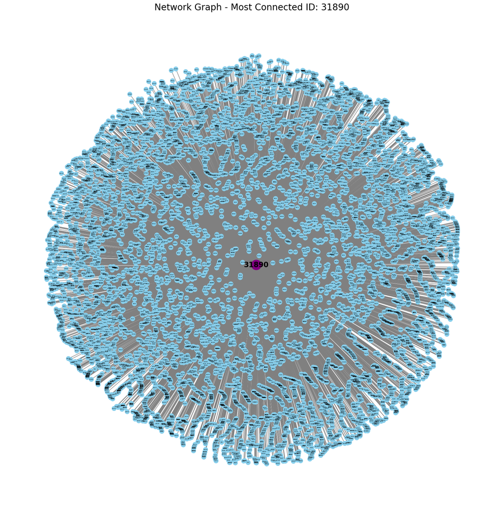

```python
# Create the graph from the most connected ID
G = nx.from_pandas_edgelist(connections_most_connencted, 'id_1', 'id_2')

# Create a figure and axis
fig, ax = plt.subplots(figsize=(20, 20))

# Draw the graph with custom node size and color for the central node
node_colors = ['purple' if node == most_connected else 'skyblue' for node in G.nodes()]
node_sizes = [500 if node == most_connected else 100 for node in G.nodes()]
pos = nx.spring_layout(G)
nx.draw(G, pos, ax=ax, node_color=node_colors, node_size=node_sizes, with_labels=False, edge_color="gray", font_size=10)
nx.draw_networkx_labels(G, pos, ax=ax, font_size=3, font_color='black')
nx.draw_networkx_labels(G, pos, labels={most_connected: most_connected}, font_size=16, font_color='black', font_weight='bold')
plt.title(f"Network Graph - Most Connected ID: {most_connected}", fontsize=20)
plt.show()
```

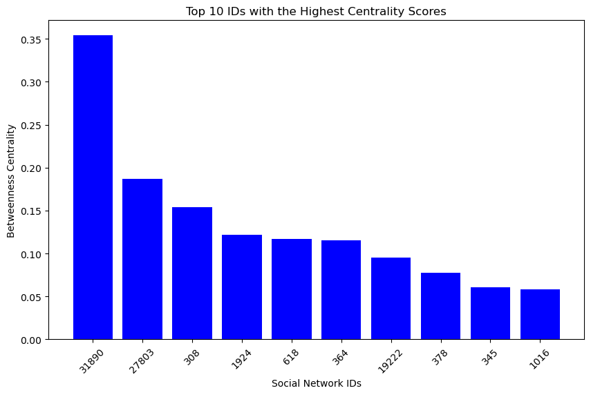

```python
# Creating a graph from the filtered SN IDs datafrome
G = nx.from_pandas_edgelist(sn_ids, 'id_1', 'id_2')

# Compute betweenness centrality for each node
betweenness = nx.betweenness_centrality(G)

# Sort the nodes based on their cetrality score
sorted_nodes = sorted(betweenness.items(), key=lambda x: x[1], reverse=True)

# Pull the top 10 centrality scores
top_ten_ids =  sorted_nodes[:10]

# Resetting the index and renaming columns for clarity
top_ten_ids = pd.DataFrame(top_ten_ids, columns=['social_network_id', 'betweenness_centrality'])

# Plot the vertical bar chart
plt.figure(figsize=(10, 6))  # Set figure size
plt.bar(social_network_id, betweenness_centrality, color='blue')  # Vertical bar plot
plt.ylabel('Betweenness Centrality')  # Label for y-axis
plt.xlabel('Social Network IDs')  # Label for x-axis
plt.title('Top 10 IDs with the Highest Centrality Scores')  # Title of the plot
plt.xticks(rotation=45)  # Rotate x-axis labels for better readability
plt.show()  # Display the plot
```

#### Reflections:

This problem took the longest to complete, partly due to the lack of lecture coverage on the topic and some confusion regarding the interpretation of part 2. I also encountered performance issues when calculating betweenness centrality, as it took a significant amount of time to run.

Throughout the process, I leveraged AI assistance primarily to troubleshoot code errors, gain insights into network structures and visualizations, and better understand betweenness centrality and its implications in network analysis.